# Risk Factor Analysis

## Outcome Variable

**Outcome Variable:** ever_co

## Predictor Variables

**Intervention Variable:** mage

**Adjustment Set:**

unadjusted

## Stratifying Variables

The analysis was stratified on these variable(s):

- agecat
- studyid
- country

## Data Summary

| agecat | studyid | country | mage | ever_co | n_cell | n |
| --- | --- | --- | --- | --- | --- | --- |
| 0-24 months | ki0047075b-MAL-ED | BANGLADESH | [20-30) | 0 | 161 | 263 |
| 0-24 months | ki0047075b-MAL-ED | BANGLADESH | [20-30) | 1 | 19 | 263 |
| 0-24 months | ki0047075b-MAL-ED | BANGLADESH | <20 | 0 | 27 | 263 |
| 0-24 months | ki0047075b-MAL-ED | BANGLADESH | <20 | 1 | 10 | 263 |
| 0-24 months | ki0047075b-MAL-ED | BANGLADESH | >=30 | 0 | 36 | 263 |
| 0-24 months | ki0047075b-MAL-ED | BANGLADESH | >=30 | 1 | 10 | 263 |
| 0-24 months | ki0047075b-MAL-ED | BRAZIL | [20-30) | 0 | 138 | 233 |
| 0-24 months | ki0047075b-MAL-ED | BRAZIL | [20-30) | 1 | 1 | 233 |
| 0-24 months | ki0047075b-MAL-ED | BRAZIL | <20 | 0 | 43 | 233 |
| 0-24 months | ki0047075b-MAL-ED | BRAZIL | <20 | 1 | 0 | 233 |
| 0-24 months | ki0047075b-MAL-ED | BRAZIL | >=30 | 0 | 50 | 233 |
| 0-24 months | ki0047075b-MAL-ED | BRAZIL | >=30 | 1 | 1 | 233 |
| 0-24 months | ki0047075b-MAL-ED | INDIA | [20-30) | 0 | 152 | 249 |
| 0-24 months | ki0047075b-MAL-ED | INDIA | [20-30) | 1 | 42 | 249 |
| 0-24 months | ki0047075b-MAL-ED | INDIA | <20 | 0 | 23 | 249 |
| 0-24 months | ki0047075b-MAL-ED | INDIA | <20 | 1 | 11 | 249 |
| 0-24 months | ki0047075b-MAL-ED | INDIA | >=30 | 0 | 21 | 249 |
| 0-24 months | ki0047075b-MAL-ED | INDIA | >=30 | 1 | 0 | 249 |
| 0-24 months | ki0047075b-MAL-ED | NEPAL | [20-30) | 0 | 174 | 240 |
| 0-24 months | ki0047075b-MAL-ED | NEPAL | [20-30) | 1 | 15 | 240 |
| 0-24 months | ki0047075b-MAL-ED | NEPAL | <20 | 0 | 3 | 240 |
| 0-24 months | ki0047075b-MAL-ED | NEPAL | <20 | 1 | 2 | 240 |
| 0-24 months | ki0047075b-MAL-ED | NEPAL | >=30 | 0 | 42 | 240 |
| 0-24 months | ki0047075b-MAL-ED | NEPAL | >=30 | 1 | 4 | 240 |
| 0-24 months | ki0047075b-MAL-ED | PERU | [20-30) | 0 | 149 | 302 |
| 0-24 months | ki0047075b-MAL-ED | PERU | [20-30) | 1 | 4 | 302 |
| 0-24 months | ki0047075b-MAL-ED | PERU | <20 | 0 | 77 | 302 |
| 0-24 months | ki0047075b-MAL-ED | PERU | <20 | 1 | 5 | 302 |
| 0-24 months | ki0047075b-MAL-ED | PERU | >=30 | 0 | 64 | 302 |
| 0-24 months | ki0047075b-MAL-ED | PERU | >=30 | 1 | 3 | 302 |

[output cut: 450 more lines]

The following strata were considered:

- agecat: 0-24 months, studyid: ki0047075b-MAL-ED, country: BANGLADESH
- agecat: 0-24 months, studyid: ki0047075b-MAL-ED, country: BRAZIL
- agecat: 0-24 months, studyid: ki0047075b-MAL-ED, country: INDIA
- agecat: 0-24 months, studyid: ki0047075b-MAL-ED, country: NEPAL
- agecat: 0-24 months, studyid: ki0047075b-MAL-ED, country: PERU
- agecat: 0-24 months, studyid: ki0047075b-MAL-ED, country: SOUTH AFRICA
- agecat: 0-24 months, studyid: ki0047075b-MAL-ED, country: TANZANIA, UNITED REPUBLIC OF
- agecat: 0-24 months, studyid: ki1000108-CMC-V-BCS-2002, country: INDIA
- agecat: 0-24 months, studyid: ki1000108-IRC, country: INDIA
- agecat: 0-24 months, studyid: ki1000109-EE, country: PAKISTAN
- agecat: 0-24 months, studyid: ki1000304b-SAS-CompFeed, country: INDIA
- agecat: 0-24 months, studyid: ki1000304b-SAS-FoodSuppl, country: INDIA
- agecat: 0-24 months, studyid: ki1017093-NIH-Birth, country: BANGLADESH
- agecat: 0-24 months, studyid: ki1017093b-PROVIDE, country: BANGLADESH
- agecat: 0-24 months, studyid: ki1017093c-NIH-Crypto, country: BANGLADESH
- agecat: 0-24 months, studyid: ki1066203-TanzaniaChild2, country: TANZANIA, UNITED REPUBLIC OF
- agecat: 0-24 months, studyid: ki1101329-Keneba, country: GAMBIA
- agecat: 0-24 months, studyid: ki1112895-Guatemala BSC, country: GUATEMALA
- agecat: 0-24 months, studyid: ki1112895-iLiNS-Zinc, country: BURKINA FASO
- agecat: 0-24 months, studyid: ki1113344-GMS-Nepal, country: NEPAL
- agecat: 0-24 months, studyid: ki1119695-PROBIT, country: BELARUS
- agecat: 0-24 months, studyid: ki1126311-ZVITAMBO, country: ZIMBABWE
- agecat: 0-24 months, studyid: ki1135781-COHORTS, country: GUATEMALA
- agecat: 0-24 months, studyid: ki1135781-COHORTS, country: INDIA
- agecat: 0-24 months, studyid: ki1135781-COHORTS, country: PHILIPPINES
- agecat: 0-24 months, studyid: ki1148112-LCNI-5, country: MALAWI
- agecat: 0-24 months, studyid: kiGH5241-JiVitA-3, country: BANGLADESH
- agecat: 0-6 months, studyid: ki0047075b-MAL-ED, country: BANGLADESH
- agecat: 0-6 months, studyid: ki0047075b-MAL-ED, country: BRAZIL
- agecat: 0-6 months, studyid: ki0047075b-MAL-ED, country: INDIA
- agecat: 0-6 months, studyid: ki0047075b-MAL-ED, country: NEPAL
- agecat: 0-6 months, studyid: ki0047075b-MAL-ED, country: PERU
- agecat: 0-6 months, studyid: ki0047075b-MAL-ED, country: SOUTH AFRICA
- agecat: 0-6 months, studyid: ki0047075b-MAL-ED, country: TANZANIA, UNITED REPUBLIC OF
- agecat: 0-6 months, studyid: ki1000108-CMC-V-BCS-2002, country: INDIA
- agecat: 0-6 months, studyid: ki1000108-IRC, country: INDIA
- agecat: 0-6 months, studyid: ki1000109-EE, country: PAKISTAN
- agecat: 0-6 months, studyid: ki1000304b-SAS-CompFeed, country: INDIA
- agecat: 0-6 months, studyid: ki1000304b-SAS-FoodSuppl, country: INDIA
- agecat: 0-6 months, studyid: ki1017093-NIH-Birth, country: BANGLADESH
- agecat: 0-6 months, studyid: ki1017093b-PROVIDE, country: BANGLADESH
- agecat: 0-6 months, studyid: ki1017093c-NIH-Crypto, country: BANGLADESH
- agecat: 0-6 months, studyid: ki1066203-TanzaniaChild2, country: TANZANIA, UNITED REPUBLIC OF
- agecat: 0-6 months, studyid: ki1101329-Keneba, country: GAMBIA
- agecat: 0-6 months, studyid: ki1112895-Guatemala BSC, country: GUATEMALA
- agecat: 0-6 months, studyid: ki1113344-GMS-Nepal, country: NEPAL
- agecat: 0-6 months, studyid: ki1119695-PROBIT, country: BELARUS
- agecat: 0-6 months, studyid: ki1126311-ZVITAMBO, country: ZIMBABWE
- agecat: 0-6 months, studyid: ki1135781-COHORTS, country: GUATEMALA
- agecat: 0-6 months, studyid: ki1135781-COHORTS, country: INDIA
- agecat: 0-6 months, studyid: ki1135781-COHORTS, country: PHILIPPINES
- agecat: 0-6 months, studyid: ki1148112-LCNI-5, country: MALAWI
- agecat: 0-6 months, studyid: kiGH5241-JiVitA-3, country: BANGLADESH
- agecat: 6-24 months, studyid: ki0047075b-MAL-ED, country: BANGLADESH
- agecat: 6-24 months, studyid: ki0047075b-MAL-ED, country: BRAZIL
- agecat: 6-24 months, studyid: ki0047075b-MAL-ED, country: INDIA
- agecat: 6-24 months, studyid: ki0047075b-MAL-ED, country: NEPAL
- agecat: 6-24 months, studyid: ki0047075b-MAL-ED, country: PERU
- agecat: 6-24 months, studyid: ki0047075b-MAL-ED, country: SOUTH AFRICA
- agecat: 6-24 months, studyid: ki0047075b-MAL-ED, country: TANZANIA, UNITED REPUBLIC OF
- agecat: 6-24 months, studyid: ki1000108-CMC-V-BCS-2002, country: INDIA
- agecat: 6-24 months, studyid: ki1000108-IRC, country: INDIA
- agecat: 6-24 months, studyid: ki1000109-EE, country: PAKISTAN
- agecat: 6-24 months, studyid: ki1000304b-SAS-CompFeed, country: INDIA
- agecat: 6-24 months, studyid: ki1000304b-SAS-FoodSuppl, country: INDIA
- agecat: 6-24 months, studyid: ki1017093-NIH-Birth, country: BANGLADESH
- agecat: 6-24 months, studyid: ki1017093b-PROVIDE, country: BANGLADESH
- agecat: 6-24 months, studyid: ki1017093c-NIH-Crypto, country: BANGLADESH
- agecat: 6-24 months, studyid: ki1066203-TanzaniaChild2, country: TANZANIA, UNITED REPUBLIC OF
- agecat: 6-24 months, studyid: ki1101329-Keneba, country: GAMBIA
- agecat: 6-24 months, studyid: ki1112895-Guatemala BSC, country: GUATEMALA
- agecat: 6-24 months, studyid: ki1112895-iLiNS-Zinc, country: BURKINA FASO
- agecat: 6-24 months, studyid: ki1113344-GMS-Nepal, country: NEPAL
- agecat: 6-24 months, studyid: ki1119695-PROBIT, country: BELARUS
- agecat: 6-24 months, studyid: ki1126311-ZVITAMBO, country: ZIMBABWE
- agecat: 6-24 months, studyid: ki1135781-COHORTS, country: GUATEMALA
- agecat: 6-24 months, studyid: ki1135781-COHORTS, country: INDIA
- agecat: 6-24 months, studyid: ki1135781-COHORTS, country: PHILIPPINES
- agecat: 6-24 months, studyid: ki1148112-LCNI-5, country: MALAWI
- agecat: 6-24 months, studyid: kiGH5241-JiVitA-3, country: BANGLADESH

### Dropped Strata

Some strata were dropped due to rare outcomes:

- agecat: 0-24 months, studyid: ki0047075b-MAL-ED, country: BRAZIL
- agecat: 0-24 months, studyid: ki0047075b-MAL-ED, country: INDIA
- agecat: 0-24 months, studyid: ki0047075b-MAL-ED, country: NEPAL
- agecat: 0-24 months, studyid: ki0047075b-MAL-ED, country: PERU
- agecat: 0-24 months, studyid: ki0047075b-MAL-ED, country: SOUTH AFRICA
- agecat: 0-24 months, studyid: ki0047075b-MAL-ED, country: TANZANIA, UNITED REPUBLIC OF
- agecat: 0-24 months, studyid: ki1000109-EE, country: PAKISTAN
- agecat: 0-24 months, studyid: ki1119695-PROBIT, country: BELARUS
- agecat: 0-6 months, studyid: ki0047075b-MAL-ED, country: BANGLADESH
- agecat: 0-6 months, studyid: ki0047075b-MAL-ED, country: BRAZIL
- agecat: 0-6 months, studyid: ki0047075b-MAL-ED, country: INDIA
- agecat: 0-6 months, studyid: ki0047075b-MAL-ED, country: NEPAL
- agecat: 0-6 months, studyid: ki0047075b-MAL-ED, country: PERU
- agecat: 0-6 months, studyid: ki0047075b-MAL-ED, country: SOUTH AFRICA
- agecat: 0-6 months, studyid: ki0047075b-MAL-ED, country: TANZANIA, UNITED REPUBLIC OF
- agecat: 0-6 months, studyid: ki1000108-CMC-V-BCS-2002, country: INDIA
- agecat: 0-6 months, studyid: ki1000108-IRC, country: INDIA
- agecat: 0-6 months, studyid: ki1000109-EE, country: PAKISTAN
- agecat: 0-6 months, studyid: ki1000304b-SAS-FoodSuppl, country: INDIA
- agecat: 0-6 months, studyid: ki1017093-NIH-Birth, country: BANGLADESH
- agecat: 0-6 months, studyid: ki1017093b-PROVIDE, country: BANGLADESH
- agecat: 0-6 months, studyid: ki1017093c-NIH-Crypto, country: BANGLADESH
- agecat: 0-6 months, studyid: ki1066203-TanzaniaChild2, country: TANZANIA, UNITED REPUBLIC OF
- agecat: 0-6 months, studyid: ki1112895-Guatemala BSC, country: GUATEMALA
- agecat: 0-6 months, studyid: ki1119695-PROBIT, country: BELARUS
- agecat: 0-6 months, studyid: ki1135781-COHORTS, country: GUATEMALA
- agecat: 0-6 months, studyid: ki1148112-LCNI-5, country: MALAWI
- agecat: 6-24 months, studyid: ki0047075b-MAL-ED, country: BRAZIL
- agecat: 6-24 months, studyid: ki0047075b-MAL-ED, country: INDIA
- agecat: 6-24 months, studyid: ki0047075b-MAL-ED, country: NEPAL
- agecat: 6-24 months, studyid: ki0047075b-MAL-ED, country: PERU
- agecat: 6-24 months, studyid: ki0047075b-MAL-ED, country: SOUTH AFRICA
- agecat: 6-24 months, studyid: ki0047075b-MAL-ED, country: TANZANIA, UNITED REPUBLIC OF
- agecat: 6-24 months, studyid: ki1000109-EE, country: PAKISTAN
- agecat: 6-24 months, studyid: ki1112895-Guatemala BSC, country: GUATEMALA
- agecat: 6-24 months, studyid: ki1119695-PROBIT, country: BELARUS

## Methods Detail

We’re interested in the causal parameters $E[Y_a]$ for all values of $a \in \mathcal{A}$. These parameters represent the mean outcome if, possibly contrary to fact, we intervened to set all units to have $A=a$. Under the randomization and positivity assumptions, these are identified by the statistical parameters $\psi_a=E_W[E_{Y|A,W}(Y|A=a,W)]$. In addition, we’re interested in the mean of $Y$, $E[Y]$ under no intervention (the observed mean). We will estimate these parameters by using SuperLearner to fit the relevant likelihood factors – $E_{Y|A,W}(Y|A=a,W)$ and $p(A=a|W)$, and then updating our likelihood fit using a joint TMLE.

For unadjusted analyses ($W=\{\}$), initial likelihoods were estimated using Lrnr_glm to estimate the simple $E(Y|A)$ and Lrnr_mean to estimate $p(A)$. For adjusted analyses, a small library containing Lrnr_glmnet, Lrnr_xgboost, and Lrnr_mean was used.

Having estimated these parameters, we will then use the delta method to estimate relative risks and attributable risks relative to a prespecified baseline level of $A$.

# Results Detail

## Results Plots

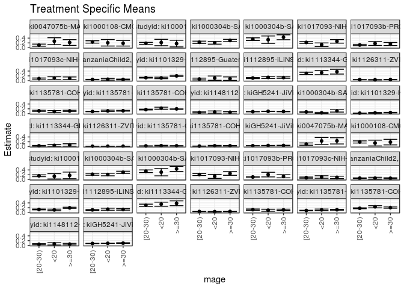

[figure not shown]

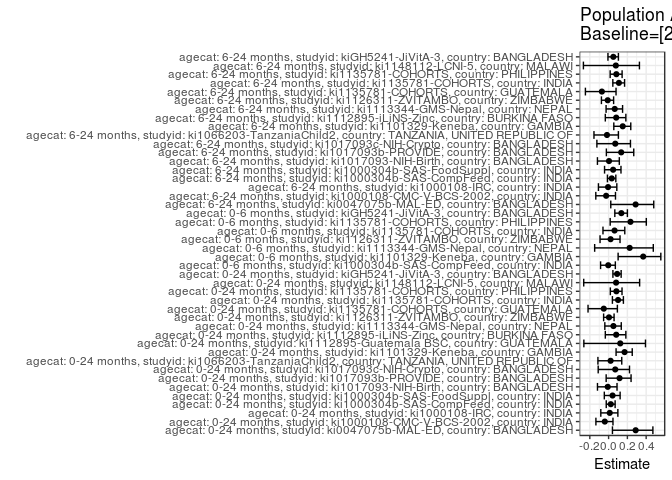

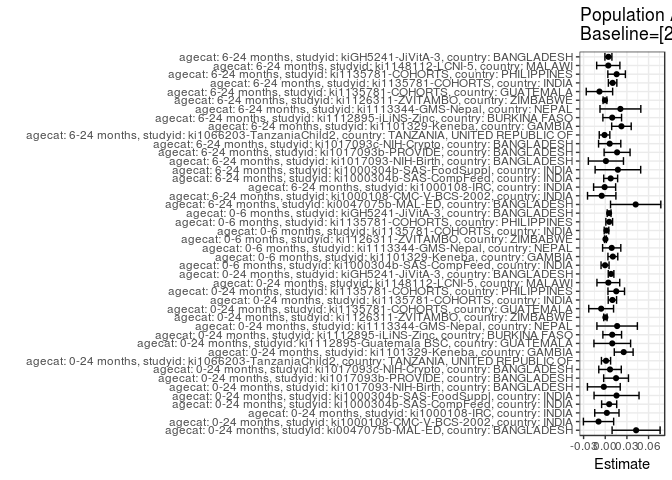

## Results Table

### Parameter: TSM

| agecat | studyid | country | intervention_level | baseline_level | estimate | ci_lower | ci_upper |
| --- | --- | --- | --- | --- | --- | --- | --- |
| 0-24 months | ki0047075b-MAL-ED | BANGLADESH | [20-30) | NA | 0.1055556 | 0.0605821 | 0.1505290 |
| 0-24 months | ki0047075b-MAL-ED | BANGLADESH | <20 | NA | 0.2702703 | 0.1269015 | 0.4136391 |
| 0-24 months | ki0047075b-MAL-ED | BANGLADESH | >=30 | NA | 0.2173913 | 0.0979678 | 0.3368148 |
| 0-24 months | ki1000108-CMC-V-BCS-2002 | INDIA | [20-30) | NA | 0.2398649 | 0.1911553 | 0.2885744 |
| 0-24 months | ki1000108-CMC-V-BCS-2002 | INDIA | <20 | NA | 0.2058824 | 0.0697869 | 0.3419778 |
| 0-24 months | ki1000108-CMC-V-BCS-2002 | INDIA | >=30 | NA | 0.1860465 | 0.0695783 | 0.3025147 |
| 0-24 months | ki1000108-IRC | INDIA | [20-30) | NA | 0.1831395 | 0.1422168 | 0.2240622 |
| 0-24 months | ki1000108-IRC | INDIA | <20 | NA | 0.2162162 | 0.0834096 | 0.3490229 |
| 0-24 months | ki1000108-IRC | INDIA | >=30 | NA | 0.1724138 | 0.0347651 | 0.3100625 |
| 0-24 months | ki1000304b-SAS-CompFeed | INDIA | [20-30) | NA | 0.2265625 | 0.1799846 | 0.2731404 |
| 0-24 months | ki1000304b-SAS-CompFeed | INDIA | <20 | NA | 0.2031250 | 0.1481601 | 0.2580899 |
| 0-24 months | ki1000304b-SAS-CompFeed | INDIA | >=30 | NA | 0.3017751 | 0.2563737 | 0.3471766 |
| 0-24 months | ki1000304b-SAS-FoodSuppl | INDIA | [20-30) | NA | 0.3551724 | 0.3000268 | 0.4103180 |
| 0-24 months | ki1000304b-SAS-FoodSuppl | INDIA | <20 | NA | 0.3333333 | 0.1791595 | 0.4875072 |
| 0-24 months | ki1000304b-SAS-FoodSuppl | INDIA | >=30 | NA | 0.4347826 | 0.3333639 | 0.5362013 |
| 0-24 months | ki1017093-NIH-Birth | BANGLADESH | [20-30) | NA | 0.2206235 | 0.1807918 | 0.2604552 |
| 0-24 months | ki1017093-NIH-Birth | BANGLADESH | <20 | NA | 0.1232877 | 0.0478090 | 0.1987664 |
| 0-24 months | ki1017093-NIH-Birth | BANGLADESH | >=30 | NA | 0.2651515 | 0.1897888 | 0.3405142 |
| 0-24 months | ki1017093b-PROVIDE | BANGLADESH | [20-30) | NA | 0.1135903 | 0.0855603 | 0.1416202 |
| 0-24 months | ki1017093b-PROVIDE | BANGLADESH | <20 | NA | 0.1764706 | 0.0953699 | 0.2575713 |
| 0-24 months | ki1017093b-PROVIDE | BANGLADESH | >=30 | NA | 0.1557377 | 0.0913483 | 0.2201271 |
| 0-24 months | ki1017093c-NIH-Crypto | BANGLADESH | [20-30) | NA | 0.0870445 | 0.0621693 | 0.1119197 |
| 0-24 months | ki1017093c-NIH-Crypto | BANGLADESH | <20 | NA | 0.1102941 | 0.0576118 | 0.1629764 |
| 0-24 months | ki1017093c-NIH-Crypto | BANGLADESH | >=30 | NA | 0.1015625 | 0.0491976 | 0.1539274 |
| 0-24 months | ki1066203-TanzaniaChild2 | TANZANIA, UNITED REPUBLIC OF | [20-30) | NA | 0.0490134 | 0.0383352 | 0.0596915 |
| 0-24 months | ki1066203-TanzaniaChild2 | TANZANIA, UNITED REPUBLIC OF | <20 | NA | 0.0598802 | 0.0238875 | 0.0958730 |
| 0-24 months | ki1066203-TanzaniaChild2 | TANZANIA, UNITED REPUBLIC OF | >=30 | NA | 0.0501567 | 0.0332165 | 0.0670970 |
| 0-24 months | ki1101329-Keneba | GAMBIA | [20-30) | NA | 0.1246518 | 0.1075640 | 0.1417396 |
| 0-24 months | ki1101329-Keneba | GAMBIA | <20 | NA | 0.1142132 | 0.0828010 | 0.1456254 |
| 0-24 months | ki1101329-Keneba | GAMBIA | >=30 | NA | 0.1998051 | 0.1753341 | 0.2242761 |

[output cut: 102 more lines]

### Parameter: E(Y)

| agecat | studyid | country | intervention_level | baseline_level | estimate | ci_lower | ci_upper |
| --- | --- | --- | --- | --- | --- | --- | --- |
| 0-24 months | ki0047075b-MAL-ED | BANGLADESH | NA | NA | 0.1482890 | 0.1052563 | 0.1913216 |
| 0-24 months | ki1000108-CMC-V-BCS-2002 | INDIA | NA | NA | 0.2305630 | 0.1877616 | 0.2733644 |
| 0-24 months | ki1000108-IRC | INDIA | NA | NA | 0.1853659 | 0.1477057 | 0.2230261 |
| 0-24 months | ki1000304b-SAS-CompFeed | INDIA | NA | NA | 0.2319894 | 0.1917264 | 0.2722524 |
| 0-24 months | ki1000304b-SAS-FoodSuppl | INDIA | NA | NA | 0.3708134 | 0.3244530 | 0.4171738 |
| 0-24 months | ki1017093-NIH-Birth | BANGLADESH | NA | NA | 0.2186495 | 0.1861408 | 0.2511582 |
| 0-24 months | ki1017093b-PROVIDE | BANGLADESH | NA | NA | 0.1285714 | 0.1037574 | 0.1533855 |
| 0-24 months | ki1017093c-NIH-Crypto | BANGLADESH | NA | NA | 0.0936675 | 0.0729118 | 0.1144233 |
| 0-24 months | ki1066203-TanzaniaChild2 | TANZANIA, UNITED REPUBLIC OF | NA | NA | 0.0500842 | 0.0413120 | 0.0588564 |
| 0-24 months | ki1101329-Keneba | GAMBIA | NA | NA | 0.1502101 | 0.1371047 | 0.1633155 |
| 0-24 months | ki1112895-Guatemala BSC | GUATEMALA | NA | NA | 0.0782918 | 0.0468271 | 0.1097565 |
| 0-24 months | ki1112895-iLiNS-Zinc | BURKINA FASO | NA | NA | 0.1192949 | 0.0996089 | 0.1389809 |
| 0-24 months | ki1113344-GMS-Nepal | NEPAL | NA | NA | 0.3205980 | 0.2832855 | 0.3579105 |
| 0-24 months | ki1126311-ZVITAMBO | ZIMBABWE | NA | NA | 0.0418076 | 0.0384798 | 0.0451354 |
| 0-24 months | ki1135781-COHORTS | GUATEMALA | NA | NA | 0.1103654 | 0.0935883 | 0.1271425 |
| 0-24 months | ki1135781-COHORTS | INDIA | NA | NA | 0.0980577 | 0.0900528 | 0.1060627 |
| 0-24 months | ki1135781-COHORTS | PHILIPPINES | NA | NA | 0.1839080 | 0.1701456 | 0.1976705 |
| 0-24 months | ki1148112-LCNI-5 | MALAWI | NA | NA | 0.0537313 | 0.0366447 | 0.0708180 |
| 0-24 months | kiGH5241-JiVitA-3 | BANGLADESH | NA | NA | 0.0885347 | 0.0846552 | 0.0924142 |
| 0-6 months | ki1000304b-SAS-CompFeed | INDIA | NA | NA | 0.0704787 | 0.0478990 | 0.0930584 |
| 0-6 months | ki1101329-Keneba | GAMBIA | NA | NA | 0.0286188 | 0.0219621 | 0.0352756 |
| 0-6 months | ki1113344-GMS-Nepal | NEPAL | NA | NA | 0.0398671 | 0.0242254 | 0.0555088 |
| 0-6 months | ki1126311-ZVITAMBO | ZIMBABWE | NA | NA | 0.0120997 | 0.0102756 | 0.0139237 |
| 0-6 months | ki1135781-COHORTS | INDIA | NA | NA | 0.0274456 | 0.0229617 | 0.0319295 |
| 0-6 months | ki1135781-COHORTS | PHILIPPINES | NA | NA | 0.0236531 | 0.0182537 | 0.0290525 |
| 0-6 months | kiGH5241-JiVitA-3 | BANGLADESH | NA | NA | 0.0393898 | 0.0369053 | 0.0418742 |
| 6-24 months | ki0047075b-MAL-ED | BANGLADESH | NA | NA | 0.1464435 | 0.1015265 | 0.1913605 |
| 6-24 months | ki1000108-CMC-V-BCS-2002 | INDIA | NA | NA | 0.1876676 | 0.1479906 | 0.2273445 |
| 6-24 months | ki1000108-IRC | INDIA | NA | NA | 0.1560976 | 0.1209228 | 0.1912723 |
| 6-24 months | ki1000304b-SAS-CompFeed | INDIA | NA | NA | 0.2260619 | 0.1909133 | 0.2612105 |
| 6-24 months | ki1000304b-SAS-FoodSuppl | INDIA | NA | NA | 0.3615960 | 0.3145115 | 0.4086805 |
| 6-24 months | ki1017093-NIH-Birth | BANGLADESH | NA | NA | 0.2092593 | 0.1749182 | 0.2436003 |
| 6-24 months | ki1017093b-PROVIDE | BANGLADESH | NA | NA | 0.1221498 | 0.0962275 | 0.1480722 |
| 6-24 months | ki1017093c-NIH-Crypto | BANGLADESH | NA | NA | 0.0863014 | 0.0659171 | 0.1066856 |
| 6-24 months | ki1066203-TanzaniaChild2 | TANZANIA, UNITED REPUBLIC OF | NA | NA | 0.0564436 | 0.0463321 | 0.0665551 |
| 6-24 months | ki1101329-Keneba | GAMBIA | NA | NA | 0.1489203 | 0.1354543 | 0.1623863 |
| 6-24 months | ki1112895-iLiNS-Zinc | BURKINA FASO | NA | NA | 0.1192949 | 0.0996089 | 0.1389809 |
| 6-24 months | ki1113344-GMS-Nepal | NEPAL | NA | NA | 0.3220339 | 0.2842988 | 0.3597690 |
| 6-24 months | ki1126311-ZVITAMBO | ZIMBABWE | NA | NA | 0.0406862 | 0.0369369 | 0.0444355 |
| 6-24 months | ki1135781-COHORTS | GUATEMALA | NA | NA | 0.1123039 | 0.0945135 | 0.1300943 |
| 6-24 months | ki1135781-COHORTS | INDIA | NA | NA | 0.0928355 | 0.0847544 | 0.1009166 |
| 6-24 months | ki1135781-COHORTS | PHILIPPINES | NA | NA | 0.1908832 | 0.1763448 | 0.2054216 |
| 6-24 months | ki1148112-LCNI-5 | MALAWI | NA | NA | 0.0546282 | 0.0372644 | 0.0719920 |
| 6-24 months | kiGH5241-JiVitA-3 | BANGLADESH | NA | NA | 0.0868936 | 0.0822329 | 0.0915543 |

### Parameter: RR

| agecat | studyid | country | intervention_level | baseline_level | estimate | ci_lower | ci_upper |
| --- | --- | --- | --- | --- | --- | --- | --- |
| 0-24 months | ki0047075b-MAL-ED | BANGLADESH | [20-30) | [20-30) | 1.0000000 | 1.0000000 | 1.0000000 |
| 0-24 months | ki0047075b-MAL-ED | BANGLADESH | <20 | [20-30) | 2.5604552 | 1.2966711 | 5.0559705 |
| 0-24 months | ki0047075b-MAL-ED | BANGLADESH | >=30 | [20-30) | 2.0594966 | 1.0276283 | 4.1274905 |
| 0-24 months | ki1000108-CMC-V-BCS-2002 | INDIA | [20-30) | [20-30) | 1.0000000 | 1.0000000 | 1.0000000 |
| 0-24 months | ki1000108-CMC-V-BCS-2002 | INDIA | <20 | [20-30) | 0.8583264 | 0.4298605 | 1.7138681 |
| 0-24 months | ki1000108-CMC-V-BCS-2002 | INDIA | >=30 | [20-30) | 0.7756305 | 0.4016362 | 1.4978796 |
| 0-24 months | ki1000108-IRC | INDIA | [20-30) | [20-30) | 1.0000000 | 1.0000000 | 1.0000000 |
| 0-24 months | ki1000108-IRC | INDIA | <20 | [20-30) | 1.1806092 | 0.6141094 | 2.2696901 |
| 0-24 months | ki1000108-IRC | INDIA | >=30 | [20-30) | 0.9414340 | 0.4109046 | 2.1569435 |
| 0-24 months | ki1000304b-SAS-CompFeed | INDIA | [20-30) | [20-30) | 1.0000000 | 1.0000000 | 1.0000000 |
| 0-24 months | ki1000304b-SAS-CompFeed | INDIA | <20 | [20-30) | 0.8965517 | 0.6447549 | 1.2466831 |
| 0-24 months | ki1000304b-SAS-CompFeed | INDIA | >=30 | [20-30) | 1.3319731 | 1.1648329 | 1.5230959 |
| 0-24 months | ki1000304b-SAS-FoodSuppl | INDIA | [20-30) | [20-30) | 1.0000000 | 1.0000000 | 1.0000000 |
| 0-24 months | ki1000304b-SAS-FoodSuppl | INDIA | <20 | [20-30) | 0.9385113 | 0.5761733 | 1.5287128 |
| 0-24 months | ki1000304b-SAS-FoodSuppl | INDIA | >=30 | [20-30) | 1.2241452 | 0.9249931 | 1.6200461 |
| 0-24 months | ki1017093-NIH-Birth | BANGLADESH | [20-30) | [20-30) | 1.0000000 | 1.0000000 | 1.0000000 |
| 0-24 months | ki1017093-NIH-Birth | BANGLADESH | <20 | [20-30) | 0.5588148 | 0.2951655 | 1.0579624 |
| 0-24 months | ki1017093-NIH-Birth | BANGLADESH | >=30 | [20-30) | 1.2018281 | 0.8582375 | 1.6829732 |
| 0-24 months | ki1017093b-PROVIDE | BANGLADESH | [20-30) | [20-30) | 1.0000000 | 1.0000000 | 1.0000000 |
| 0-24 months | ki1017093b-PROVIDE | BANGLADESH | <20 | [20-30) | 1.5535714 | 0.9221259 | 2.6174129 |
| 0-24 months | ki1017093b-PROVIDE | BANGLADESH | >=30 | [20-30) | 1.3710480 | 0.8471197 | 2.2190165 |
| 0-24 months | ki1017093c-NIH-Crypto | BANGLADESH | [20-30) | [20-30) | 1.0000000 | 1.0000000 | 1.0000000 |
| 0-24 months | ki1017093c-NIH-Crypto | BANGLADESH | <20 | [20-30) | 1.2670999 | 0.7262332 | 2.2107802 |
| 0-24 months | ki1017093c-NIH-Crypto | BANGLADESH | >=30 | [20-30) | 1.1667878 | 0.6471093 | 2.1038082 |
| 0-24 months | ki1066203-TanzaniaChild2 | TANZANIA, UNITED REPUBLIC OF | [20-30) | [20-30) | 1.0000000 | 1.0000000 | 1.0000000 |
| 0-24 months | ki1066203-TanzaniaChild2 | TANZANIA, UNITED REPUBLIC OF | <20 | [20-30) | 1.2217124 | 0.6446233 | 2.3154317 |
| 0-24 months | ki1066203-TanzaniaChild2 | TANZANIA, UNITED REPUBLIC OF | >=30 | [20-30) | 1.0233278 | 0.6846442 | 1.5295532 |
| 0-24 months | ki1101329-Keneba | GAMBIA | [20-30) | [20-30) | 1.0000000 | 1.0000000 | 1.0000000 |
| 0-24 months | ki1101329-Keneba | GAMBIA | <20 | [20-30) | 0.9162578 | 0.6738421 | 1.2458829 |
| 0-24 months | ki1101329-Keneba | GAMBIA | >=30 | [20-30) | 1.6029055 | 1.3337461 | 1.9263830 |

[output cut: 102 more lines]

### Parameter: PAR

| agecat | studyid | country | intervention_level | baseline_level | estimate | ci_lower | ci_upper |
| --- | --- | --- | --- | --- | --- | --- | --- |
| 0-24 months | ki0047075b-MAL-ED | BANGLADESH | [20-30) | NA | 0.0427334 | 0.0094795 | 0.0759874 |
| 0-24 months | ki1000108-CMC-V-BCS-2002 | INDIA | [20-30) | NA | -0.0093019 | -0.0302523 | 0.0116486 |
| 0-24 months | ki1000108-IRC | INDIA | [20-30) | NA | 0.0022263 | -0.0145899 | 0.0190425 |
| 0-24 months | ki1000304b-SAS-CompFeed | INDIA | [20-30) | NA | 0.0054269 | -0.0050242 | 0.0158780 |
| 0-24 months | ki1000304b-SAS-FoodSuppl | INDIA | [20-30) | NA | 0.0156410 | -0.0155152 | 0.0467972 |
| 0-24 months | ki1017093-NIH-Birth | BANGLADESH | [20-30) | NA | -0.0019740 | -0.0246909 | 0.0207429 |
| 0-24 months | ki1017093b-PROVIDE | BANGLADESH | [20-30) | NA | 0.0149812 | -0.0021866 | 0.0321489 |
| 0-24 months | ki1017093c-NIH-Crypto | BANGLADESH | [20-30) | NA | 0.0066230 | -0.0089669 | 0.0222129 |
| 0-24 months | ki1066203-TanzaniaChild2 | TANZANIA, UNITED REPUBLIC OF | [20-30) | NA | 0.0010708 | -0.0052689 | 0.0074105 |
| 0-24 months | ki1101329-Keneba | GAMBIA | [20-30) | NA | 0.0255583 | 0.0125154 | 0.0386011 |
| 0-24 months | ki1112895-Guatemala BSC | GUATEMALA | [20-30) | NA | 0.0097204 | -0.0156673 | 0.0351081 |
| 0-24 months | ki1112895-iLiNS-Zinc | BURKINA FASO | [20-30) | NA | 0.0096508 | -0.0032819 | 0.0225836 |
| 0-24 months | ki1113344-GMS-Nepal | NEPAL | [20-30) | NA | 0.0164743 | -0.0115542 | 0.0445028 |
| 0-24 months | ki1126311-ZVITAMBO | ZIMBABWE | [20-30) | NA | 0.0001766 | -0.0021513 | 0.0025045 |
| 0-24 months | ki1135781-COHORTS | GUATEMALA | [20-30) | NA | -0.0056651 | -0.0228520 | 0.0115217 |
| 0-24 months | ki1135781-COHORTS | INDIA | [20-30) | NA | 0.0099042 | 0.0041175 | 0.0156909 |
| 0-24 months | ki1135781-COHORTS | PHILIPPINES | [20-30) | NA | 0.0152267 | 0.0037572 | 0.0266963 |
| 0-24 months | ki1148112-LCNI-5 | MALAWI | [20-30) | NA | 0.0042808 | -0.0114972 | 0.0200588 |
| 0-24 months | kiGH5241-JiVitA-3 | BANGLADESH | [20-30) | NA | 0.0080421 | 0.0041429 | 0.0119412 |
| 0-6 months | ki1000304b-SAS-CompFeed | INDIA | [20-30) | NA | -0.0002636 | -0.0057992 | 0.0052719 |
| 0-6 months | ki1101329-Keneba | GAMBIA | [20-30) | NA | 0.0105465 | 0.0037326 | 0.0173605 |
| 0-6 months | ki1113344-GMS-Nepal | NEPAL | [20-30) | NA | 0.0089393 | -0.0036604 | 0.0215390 |
| 0-6 months | ki1126311-ZVITAMBO | ZIMBABWE | [20-30) | NA | 0.0002552 | -0.0010306 | 0.0015409 |
| 0-6 months | ki1135781-COHORTS | INDIA | [20-30) | NA | 0.0017379 | -0.0014513 | 0.0049271 |
| 0-6 months | ki1135781-COHORTS | PHILIPPINES | [20-30) | NA | 0.0055113 | 0.0008411 | 0.0101814 |
| 0-6 months | kiGH5241-JiVitA-3 | BANGLADESH | [20-30) | NA | 0.0053496 | 0.0026985 | 0.0080007 |
| 6-24 months | ki0047075b-MAL-ED | BANGLADESH | [20-30) | NA | 0.0421490 | 0.0073244 | 0.0769737 |
| 6-24 months | ki1000108-CMC-V-BCS-2002 | INDIA | [20-30) | NA | -0.0049000 | -0.0245550 | 0.0147550 |
| 6-24 months | ki1000108-IRC | INDIA | [20-30) | NA | -0.0008792 | -0.0161369 | 0.0143785 |
| 6-24 months | ki1000304b-SAS-CompFeed | INDIA | [20-30) | NA | 0.0075189 | -0.0021137 | 0.0171514 |
| 6-24 months | ki1000304b-SAS-FoodSuppl | INDIA | [20-30) | NA | 0.0175100 | -0.0140696 | 0.0490895 |
| 6-24 months | ki1017093-NIH-Birth | BANGLADESH | [20-30) | NA | 0.0009259 | -0.0233964 | 0.0252482 |
| 6-24 months | ki1017093b-PROVIDE | BANGLADESH | [20-30) | NA | 0.0164027 | -0.0015755 | 0.0343810 |
| 6-24 months | ki1017093c-NIH-Crypto | BANGLADESH | [20-30) | NA | 0.0061326 | -0.0092558 | 0.0215210 |
| 6-24 months | ki1066203-TanzaniaChild2 | TANZANIA, UNITED REPUBLIC OF | [20-30) | NA | -0.0009837 | -0.0083121 | 0.0063447 |
| 6-24 months | ki1101329-Keneba | GAMBIA | [20-30) | NA | 0.0224233 | 0.0088960 | 0.0359507 |
| 6-24 months | ki1112895-iLiNS-Zinc | BURKINA FASO | [20-30) | NA | 0.0096508 | -0.0032819 | 0.0225836 |
| 6-24 months | ki1113344-GMS-Nepal | NEPAL | [20-30) | NA | 0.0209868 | -0.0072769 | 0.0492505 |
| 6-24 months | ki1126311-ZVITAMBO | ZIMBABWE | [20-30) | NA | -0.0003827 | -0.0030226 | 0.0022573 |
| 6-24 months | ki1135781-COHORTS | GUATEMALA | [20-30) | NA | -0.0080351 | -0.0263150 | 0.0102448 |
| 6-24 months | ki1135781-COHORTS | INDIA | [20-30) | NA | 0.0101958 | 0.0043374 | 0.0160542 |
| 6-24 months | ki1135781-COHORTS | PHILIPPINES | [20-30) | NA | 0.0157487 | 0.0035919 | 0.0279055 |
| 6-24 months | ki1148112-LCNI-5 | MALAWI | [20-30) | NA | 0.0042081 | -0.0118680 | 0.0202841 |
| 6-24 months | kiGH5241-JiVitA-3 | BANGLADESH | [20-30) | NA | 0.0043774 | -0.0004791 | 0.0092338 |

### Parameter: PAF

| agecat | studyid | country | intervention_level | baseline_level | estimate | ci_lower | ci_upper |
| --- | --- | --- | --- | --- | --- | --- | --- |
| 0-24 months | ki0047075b-MAL-ED | BANGLADESH | [20-30) | NA | 0.2881766 | 0.0409567 | 0.4716688 |
| 0-24 months | ki1000108-CMC-V-BCS-2002 | INDIA | [20-30) | NA | -0.0403441 | -0.1351701 | 0.0465606 |
| 0-24 months | ki1000108-IRC | INDIA | [20-30) | NA | 0.0120104 | -0.0829843 | 0.0986726 |
| 0-24 months | ki1000304b-SAS-CompFeed | INDIA | [20-30) | NA | 0.0233930 | -0.0250665 | 0.0695616 |
| 0-24 months | ki1000304b-SAS-FoodSuppl | INDIA | [20-30) | NA | 0.0421802 | -0.0456597 | 0.1226411 |
| 0-24 months | ki1017093-NIH-Birth | BANGLADESH | [20-30) | NA | -0.0090281 | -0.1184575 | 0.0896948 |
| 0-24 months | ki1017093b-PROVIDE | BANGLADESH | [20-30) | NA | 0.1165202 | -0.0259894 | 0.2392352 |
| 0-24 months | ki1017093c-NIH-Crypto | BANGLADESH | [20-30) | NA | 0.0707076 | -0.1108536 | 0.2225940 |
| 0-24 months | ki1066203-TanzaniaChild2 | TANZANIA, UNITED REPUBLIC OF | [20-30) | NA | 0.0213802 | -0.1136953 | 0.1400729 |
| 0-24 months | ki1101329-Keneba | GAMBIA | [20-30) | NA | 0.1701502 | 0.0796144 | 0.2517802 |
| 0-24 months | ki1112895-Guatemala BSC | GUATEMALA | [20-30) | NA | 0.1241558 | -0.2635432 | 0.3928953 |
| 0-24 months | ki1112895-iLiNS-Zinc | BURKINA FASO | [20-30) | NA | 0.0808990 | -0.0349734 | 0.1837988 |
| 0-24 months | ki1113344-GMS-Nepal | NEPAL | [20-30) | NA | 0.0513861 | -0.0401714 | 0.1348847 |
| 0-24 months | ki1126311-ZVITAMBO | ZIMBABWE | [20-30) | NA | 0.0042239 | -0.0530421 | 0.0583757 |
| 0-24 months | ki1135781-COHORTS | GUATEMALA | [20-30) | NA | -0.0513307 | -0.2190147 | 0.0932872 |
| 0-24 months | ki1135781-COHORTS | INDIA | [20-30) | NA | 0.1010038 | 0.0405075 | 0.1576857 |
| 0-24 months | ki1135781-COHORTS | PHILIPPINES | [20-30) | NA | 0.0827953 | 0.0184538 | 0.1429192 |
| 0-24 months | ki1148112-LCNI-5 | MALAWI | [20-30) | NA | 0.0796703 | -0.2648804 | 0.3303662 |
| 0-24 months | kiGH5241-JiVitA-3 | BANGLADESH | [20-30) | NA | 0.0908350 | 0.0459065 | 0.1336478 |
| 0-6 months | ki1000304b-SAS-CompFeed | INDIA | [20-30) | NA | -0.0037406 | -0.0854510 | 0.0718188 |
| 0-6 months | ki1101329-Keneba | GAMBIA | [20-30) | NA | 0.3685175 | 0.1014346 | 0.5562147 |
| 0-6 months | ki1113344-GMS-Nepal | NEPAL | [20-30) | NA | 0.2242268 | -0.1484932 | 0.4759882 |
| 0-6 months | ki1126311-ZVITAMBO | ZIMBABWE | [20-30) | NA | 0.0210899 | -0.0911038 | 0.1217472 |
| 0-6 months | ki1135781-COHORTS | INDIA | [20-30) | NA | 0.0633222 | -0.0598998 | 0.1722186 |
| 0-6 months | ki1135781-COHORTS | PHILIPPINES | [20-30) | NA | 0.2330035 | 0.0168622 | 0.4016264 |
| 0-6 months | kiGH5241-JiVitA-3 | BANGLADESH | [20-30) | NA | 0.1358114 | 0.0662592 | 0.2001829 |
| 6-24 months | ki0047075b-MAL-ED | BANGLADESH | [20-30) | NA | 0.2878177 | 0.0231064 | 0.4807995 |
| 6-24 months | ki1000108-CMC-V-BCS-2002 | INDIA | [20-30) | NA | -0.0261100 | -0.1362897 | 0.0733861 |
| 6-24 months | ki1000108-IRC | INDIA | [20-30) | NA | -0.0056323 | -0.1082792 | 0.0875077 |
| 6-24 months | ki1000304b-SAS-CompFeed | INDIA | [20-30) | NA | 0.0332602 | -0.0125375 | 0.0769865 |
| 6-24 months | ki1000304b-SAS-FoodSuppl | INDIA | [20-30) | NA | 0.0484242 | -0.0430622 | 0.1318864 |
| 6-24 months | ki1017093-NIH-Birth | BANGLADESH | [20-30) | NA | 0.0044248 | -0.1188612 | 0.1141260 |
| 6-24 months | ki1017093b-PROVIDE | BANGLADESH | [20-30) | NA | 0.1342835 | -0.0236529 | 0.2678524 |
| 6-24 months | ki1017093c-NIH-Crypto | BANGLADESH | [20-30) | NA | 0.0710602 | -0.1247224 | 0.2327626 |
| 6-24 months | ki1066203-TanzaniaChild2 | TANZANIA, UNITED REPUBLIC OF | [20-30) | NA | -0.0174281 | -0.1558754 | 0.1044365 |
| 6-24 months | ki1101329-Keneba | GAMBIA | [20-30) | NA | 0.1505726 | 0.0555025 | 0.2360733 |
| 6-24 months | ki1112895-iLiNS-Zinc | BURKINA FASO | [20-30) | NA | 0.0808990 | -0.0349734 | 0.1837988 |
| 6-24 months | ki1113344-GMS-Nepal | NEPAL | [20-30) | NA | 0.0651695 | -0.0268079 | 0.1489078 |
| 6-24 months | ki1126311-ZVITAMBO | ZIMBABWE | [20-30) | NA | -0.0094058 | -0.0764168 | 0.0534335 |
| 6-24 months | ki1135781-COHORTS | GUATEMALA | [20-30) | NA | -0.0715478 | -0.2469980 | 0.0792168 |
| 6-24 months | ki1135781-COHORTS | INDIA | [20-30) | NA | 0.1098266 | 0.0450690 | 0.1701927 |
| 6-24 months | ki1135781-COHORTS | PHILIPPINES | [20-30) | NA | 0.0825044 | 0.0167433 | 0.1438673 |
| 6-24 months | ki1148112-LCNI-5 | MALAWI | [20-30) | NA | 0.0770308 | -0.2683220 | 0.3283471 |
| 6-24 months | kiGH5241-JiVitA-3 | BANGLADESH | [20-30) | NA | 0.0503761 | -0.0070465 | 0.1045244 |